# Assignment 6

In this assignment, you'll analyze a collection of data sets from the [San Francisco Open Data Portal](http://data.sfgov.org/) and [Zillow](https://www.zillow.com/). The data sets have been stored in the SQLite database `sf_data.sqlite`, which you can [download here](http://anson.ucdavis.edu/~nulle/sf_data.sqlite). The database contains the following tables:

| Table | Description |
| --- | --- |
| `crime` | Crime reports dating back to 2010. |
| `mobile_food_locations` | List of all locations where mobile food vendors sell. |
| `mobile_food_permits` | List of all mobile food vendor permits. More details [here](https://data.sfgov.org/api/views/rqzj-sfat/files/8g2f5RV4PEk0_b24iJEtgEet9gnh_eA27GlqoOjjK4k?download=true&filename=DPW_DataDictionary_Mobil… |
| `mobile_food_schedule` | Schedules for mobile food vendors. |
| `noise` | Noise complaints dating back to August 2015. |
| `parking` | List of all parking lots. |
| `parks` | List of all parks. |
| `schools` | List of all schools. |
| `zillow` | Zillow rent and housing statistics dating back to 1996. More details [here](https://www.zillow.com/research/data/). |

The `mobile_food_` tables are explicitly connected through the `locationid` and `permit` columns. The other tables are not connected, but you may be able to connect them using dates, latitude/longitude, or postal codes.

Shapefiles for US postal codes are available [here](https://www.census.gov/geo/maps-data/data/cbf/cbf_zcta.html). These may be useful for converting latitude/longitude to postal codes.

Shapefiles for San Francisco Neighborhoods are available [here](https://data.sfgov.org/Geographic-Locations-and-Boundaries/SF-Find-Neighborhoods/pty2-tcw4).

```python
import sqlite3 as sql
import sqlalchemy as sqla
import pandas as pd
import seaborn as sns
%matplotlib inline
import matplotlib.pyplot as plt
import numpy as np
plt.rcParams['figure.figsize'] = (12, 12)
db = sqla.create_engine('sqlite:///sf_data.sqlite')

cursor = db.execute("SELECT * FROM sqlite_master")
rows = cursor.fetchall()
```

**Exercise 1.1.** Which mobile food vendor(s) sells at the most locations?

```python
pd.read_sql("SELECT * FROM sqlite_master", db)
```

|  | type | name | tbl_name | rootpage | sql |
| --- | --- | --- | --- | --- | --- |
| 0 | table | crime | crime | 2 | CREATE TABLE "crime" (\n"IncidntNum" INTEGER,\... |
| 1 | table | noise | noise | 35775 | CREATE TABLE "noise" (\n"CaseID" INTEGER,\n "... |
| 2 | table | parking | parking | 35921 | CREATE TABLE "parking" (\n"Owner" TEXT,\n "Ad... |
| 3 | table | schools | schools | 35944 | CREATE TABLE "schools" (\n"Name" TEXT,\n "Ent... |
| 4 | table | parks | parks | 35961 | CREATE TABLE "parks" (\n"Name" TEXT,\n "Type"... |
| 5 | table | zillow | zillow | 35967 | CREATE TABLE "zillow" (\n"RegionName" INTEGER,... |
| 6 | table | mobile_food_permits | mobile_food_permits | 36050 | CREATE TABLE "mobile_food_permits" (\n"permit"... |
| 7 | table | mobile_food_locations | mobile_food_locations | 36060 | CREATE TABLE "mobile_food_locations" (\n"locat... |
| 8 | table | mobile_food_schedule | mobile_food_schedule | 36079 | CREATE TABLE "mobile_food_schedule" (\n"locati... |
| 9 | table | location | location | 36105 | CREATE TABLE location(\n locationid INT,\n p... |
| 10 | table | ls | ls | 36522 | CREATE TABLE ls(\n locationid INT,\n permit ... |
| 11 | table | permitSchedule | permitSchedule | 36210 | CREATE TABLE permitSchedule(\n permit TEXT,\n... |

```python
pd.read_sql("SELECT * FROM mobile_food_schedule LIMIT 1 ",db)
#nothing for 0040, but 0070 is off the grid. requesting permit still
```

|  | locationid | permit | DayOfWeek | EndHour | StartHour |
| --- | --- | --- | --- | --- | --- |
| 0 | 305727 | 11MFF-0040 | Mo | 15 | 10 |

```python
pd.read_sql("SELECT * FROM mobile_food_locations LIMIT 1",db)
```

|  | locationid | LocationDescription | Address | Latitude | Longitude |
| --- | --- | --- | --- | --- | --- |
| 0 | 762182 | TOWNSEND ST: 05TH ST to 06TH ST (400 - 499) | 444 TOWNSEND ST | 37.774871 | -122.398532 |

```python
approved=pd.read_sql("SELECT * FROM mobile_food_permits WHERE Status = 'APPROVED' LIMIT 2",db)
approved
```

|  | permit | Status | Applicant | FacilityType | FoodItems | PriorPermit | Approved | Expiration |
| --- | --- | --- | --- | --- | --- | --- | --- | --- |
| 0 | 16MFF-0027 | APPROVED | F & C Catering | Truck | Cold Truck: Hot/Cold Sandwiches: Water: Soda: ... | 1 | 2016-03-09 12:00:00 | 2017-03-15 12:00:00 |
| 1 | 16MFF-0069 | APPROVED | Munch A Bunch | Truck | Cold Truck: packaged sandwiches: pitas: breakf... | 1 | 2016-03-15 12:00:00 | 2017-03-15 12:00:00 |

```python
db.execute("CREATE TABLE ls AS SELECT * FROM mobile_food_schedule INNER JOIN mobile_food_locations ON mobile_food_locations.locationid = mobile_food_schedule.locationid ")

#db.execute("CREATE TABLE NewTable AS SELECT * FROM Parts WHERE Weight > 14")
#INNER JOIN SupplierParts ON Parts.PartID = SupplierParts.PartID", db
```

```python
pd.read_sql("SELECT * FROM ls LIMIT 1",db)
```

|  | locationid | permit | DayOfWeek | EndHour | StartHour | locationid:1 | LocationDescription | Address | Latitude | Longitude |
| --- | --- | --- | --- | --- | --- | --- | --- | --- | --- | --- |
| 0 | 305727 | 11MFF-0040 | Mo | 15 | 10 | 305727 | MISSION ST: SHAW ALY to ANTHONY ST (543 - 586) | 561 MISSION ST | 0.0 | 0.0 |

```python
db.execute("CREATE TABLE permitSchedule AS SELECT * FROM mobile_food_permits INNER JOIN ls ON ls.permit = mobile_food_permits.permit")
```

```python
PS=pd.read_sql("SELECT LocationDescription,Applicant FROM permitSchedule WHERE LocationDescription IS NOT NULL ",db)
PS=PS.drop_duplicates(keep='last')
PS['Applicant'].value_counts()
```

```
May Catering                                        52
Anas Goodies Catering                               34
Natan's Catering                                    25
Liang Bai Ping                                      24
Singh Brothers Ice Cream                            21
Sun Rise Catering                                   18
Mang Hang Catering                                  18
John's Catering #5                                  18
Park's Catering                                     18
Two G's Catering                                    16
D & T Catering                                      16
Mini Mobile Food Catering                           15
Steve's Mobile Deli                                 15
Quan Catering                                       14
M M Catering                                        13
Mike's Catering                                     11
F & C Catering                                      11
Bach Catering                                       10
Munch A Bunch                                       10
Roadside Rotisserie Corporation / Country Grill      7
BH & MT LLC                                          7
Linda's Catering                                     6
Off the Grid Services, LLC                           6
Eva's Catering                                       6
Cheese Gone Wild                                     5
Casey's Pizza, LLC                                   5
Covered Dish Productions, LLC. dba. The Rib Whip     5
San Francisco Street Foods, Inc.                     5
Golden Catering                                      5
Lobsta Truck                                         5
                                                    ..
Bob Johnson                                          1
Eli's Hot Dogs                                       1
Breaking Bread Inc.                                  1
La Jefa                                              1
Mr. Nice, LLC                                        1
Your Community Foods                                 1
Peruchi Food Truck,LLC                               1
El Gallo Jiro                                        1
Raspados El Yocateco                                 1
The Creme Brulee Cart                                1
Stanley Roth                                         1
Curbside Coffee                                      1
Wexler, LLC                                          1
Geary Cocina                                         1
Faith Sandwich                                       1
SF Cart Project                                      1
Got Snacks                                           1
Golden Gate Halal Food                               1
Rita's Catering                                      1
Munch India                                          1
Leo's Hot Dogs                                       1
Mob Dog                                              1
Bonito Poke                                          1
Kabob Trolley, LLC                                   1
Sausage Slinger                                      1
Curry Up Now                                         1
Kiss Point                                           1
Missing Link SF                                      1
Mario's Colombian and Mexican Food                   1
Alfaro's Truck                                       1
Name: Applicant, dtype: int64
```

# Which mobile food vendor(s) sells at the most locations?

May Catering is the food vendor that sells at the most locations of 52. The second largest food vendor would be Anas Goodies with 34 locations. In third is Natan's Catering with 25 different locations.

**Exercise 1.2.** Ask and use the database to analyze 5 questions about San Francisco. For each question, write at least 150 words and support your answer with plots. Make a map for at least 2 of the 5 questions.

You should try to come up with some questions on your own, but these are examples of reasonable questions:

- Which parts of the city are the most and least expensive?
- Which parts of the city are the most dangerous (and at what times)?
- Are noise complaints and mobile food vendors related?
- What are the best times and places to find food trucks?
- Is there a relationship between housing prices and any of the other tables?

Please make sure to clearly state each of your questions in your submission.

```python
pd.read_sql("SELECT * FROM zillow LIMIT 2",db)
```

|  | RegionName | Date | ZriPerSqft_AllHomes | MedianSoldPricePerSqft_AllHomes | PriceToRentRatio_AllHomes | Turnover_AllHomes |
| --- | --- | --- | --- | --- | --- | --- |
| 0 | 94109 | 2010-11-01 00:00:00 | 3.156 | 675.1913 | 19.14 | 6.0771 |
| 1 | 94110 | 2010-11-01 00:00:00 | 2.566 | 599.6785 | 18.10 | 5.4490 |

# Which parts of the city are the most and least expensive?

```python
pd.read_sql("SELECT RegionName, AVG(MedianSoldPricePerSqft_AllHomes) AS Avg_Sqft_Home FROM zillow GROUP BY RegionName LIMIT 5", db)
```

|  | RegionName | Avg_Sqft_Home |
| --- | --- | --- |
| 0 | 94080 | 375.629802 |
| 1 | 94102 | 626.417276 |
| 2 | 94103 | 604.009929 |
| 3 | 94104 | 1336.128581 |
| 4 | 94105 | 798.257824 |

```python
avg_rent=pd.read_sql("SELECT RegionName, AVG(MedianSoldPricePerSqft_AllHomes) AS Avg_Sqft_Home FROM zillow GROUP BY RegionName", db)
avg_rent.max()
```

```
RegionName       94158.000000
Avg_Sqft_Home     1336.128581
dtype: float64
```

```python
avg_rent.min()
```

```
RegionName       94080.000000
Avg_Sqft_Home      297.008046
dtype: float64
```

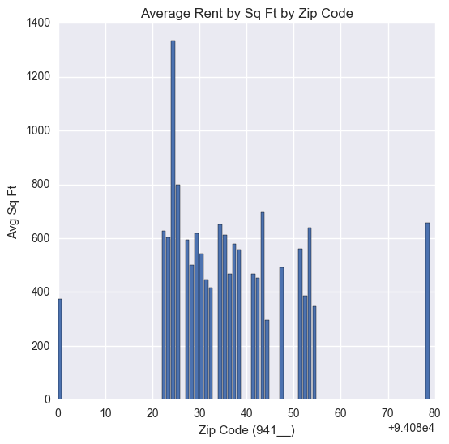

```python
x = list(avg_rent['RegionName'])
y=list(avg_rent['Avg_Sqft_Home'])
plt.bar(x, y)
plt.ylabel("Avg Sq Ft")
plt.xlabel("Zip Code (941__)")
plt.title("Average Rent by Sq Ft by Zip Code")
plt.show()
```

# What parts of the city are the most dangerous? (And what times?)

```python
pd.read_sql("SELECT * FROM crime LIMIT 2 ",db)
```

|  | IncidntNum | Category | Descript | DayOfWeek | Datetime | PdDistrict | Resolution | Address | Lon | Lat |
| --- | --- | --- | --- | --- | --- | --- | --- | --- | --- | --- |
| 0 | 150060275 | NON-CRIMINAL | LOST PROPERTY | Monday | 2015-01-19 14:00:00 | MISSION | NONE | 18TH ST / VALENCIA ST | -122.421582 | 37.761701 |
| 1 | 150098210 | ROBBERY | ROBBERY, BODILY FORCE | Sunday | 2015-02-01 15:45:00 | TENDERLOIN | NONE | 300 Block of LEAVENWORTH ST | -122.414406 | 37.784191 |

```python
crime_count=pd.read_sql("SELECT Category, COUNT(*) AS Count FROM crime GROUP BY Category", db)
```

```python
crime_count=crime_count.sort_values(by=["Count"], ascending=[False])
crime_count.head()
```

|  | Category | Count |
| --- | --- | --- |
| 16 | LARCENY/THEFT | 243144 |
| 21 | OTHER OFFENSES | 141431 |
| 20 | NON-CRIMINAL | 125702 |
| 1 | ASSAULT | 90029 |
| 35 | VANDALISM | 54467 |

```python
crime1=crime_count.drop([20,21])
crime1['Count']
```

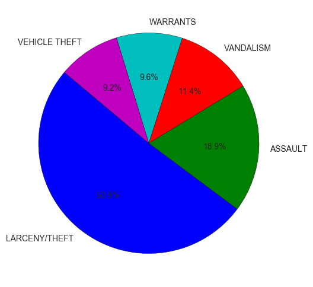

```python
counts=list(crime1.head()['Count'])
counts
labels=list(crime1.head()['Category'])
plt.rcParams["figure.figsize"] = (6,6)
plt.pie(counts,labels=labels,autopct='%1.1F%%',startangle=140)
plt.show()
```

# What regions have the most amount of noise complaints?

```python
noise_complaint=pd.read_sql("SELECT * FROM noise",db)
```

```python
from mpl_toolkits.basemap import Basemap
```

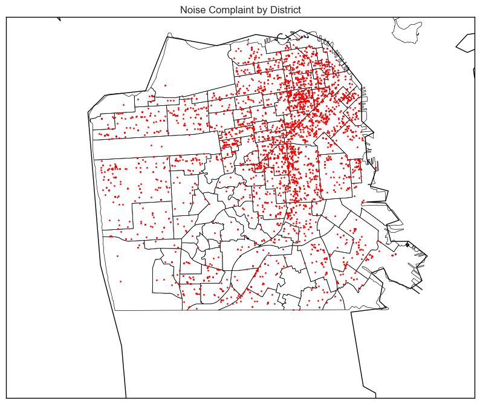

```python
fig,ax=plt.subplots(figsize=(10,20))
noisemap = Basemap(llcrnrlon = -122.553864, llcrnrlat = 37.675669, urcrnrlon=-122.334137,urcrnrlat = 37.816836,resolution = 'h', projection = 'merc')
noisemap.drawmapboundary(fill_color = 'white')
noisemap.drawcoastlines() #maybe dun need
noisemap.readshapefile("geo_export_9c1e2bde-8fa4-45cf-aa3a-7959911db8f7", 'districts')

for lon,lat in zip(noise_complaint.Lon,noise_complaint.Lat):
    x,y=noisemap(lon,lat)
    noisemap.plot(x,y,'ro',markersize=2)
plt.title('Noise Complaint by District')
plt.show()
```

The red dots indicate all of the locations where there was a noise complaint reported. It appears that the highest density of these reports is in the downtown area of San Francisco. This is expected because this region of San Francisco has the highest density of population and businesses. There are many companies, restaurants, and homes in the financial district so it is realistic that this area would be so loud.

# Parks

```python
park=pd.read_sql('SELECT * FROM parks ',db)
```

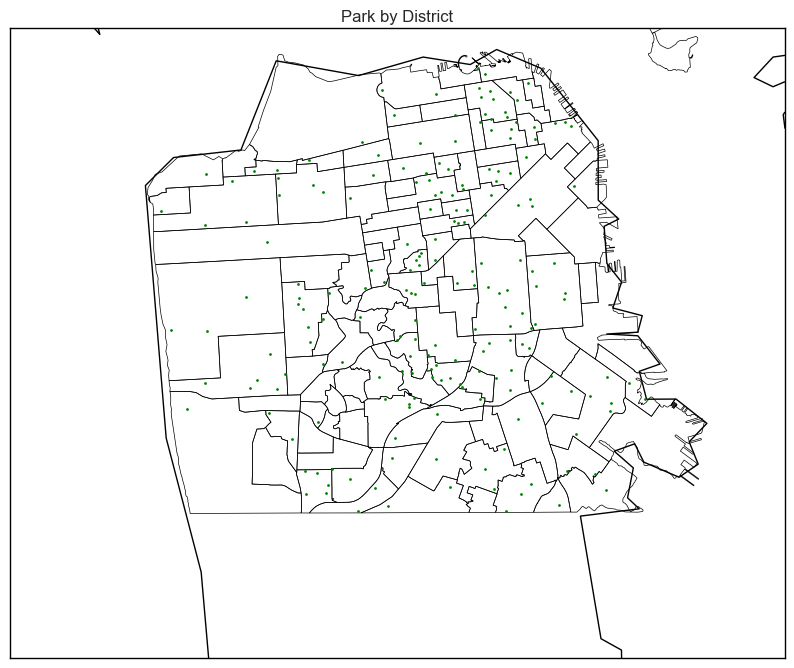

```python
fig,ax=plt.subplots(figsize=(10,20))
parkmap = Basemap(llcrnrlon = -122.553864, llcrnrlat = 37.675669, urcrnrlon=-122.334137,urcrnrlat = 37.816836,resolution = 'h', projection = 'merc')
parkmap.drawmapboundary(fill_color = 'white')
parkmap.drawcoastlines()
parkmap.readshapefile("geo_export_9c1e2bde-8fa4-45cf-aa3a-7959911db8f7", 'districts')

for lon,lat in zip(park.Lon,park.Lat):
    x,y=parkmap(lon,lat)
    parkmap.plot(x,y,'go',markersize=2)
plt.title('Park by District')
plt.show()
```

This plot shows the location of parks in San Francisco, split by the districts. There does not appear to be any sort of clustering of parks, which makes sense. It is unnecessary to have so many parks all in one close proximity.

# How many schools are there?

```python
pd.read_sql('SELECT * FROM schools LIMIT 3',db)
```

|  | Name | Entity | LowerGrade | UpperGrade | GradeRange | Category | LowerAge | UpperAge | GeneralType | Address | Lat | Lon |
| --- | --- | --- | --- | --- | --- | --- | --- | --- | --- | --- | --- | --- |
| 0 | Alamo Elementary School | SFUSD | 0 | 5 | K-5 | USD Grades K-5 | 5 | 10 | PS | 250 23RD AVE, San Francisco, CA 94121 | 37.783005 | -122.482300 |
| 1 | Alvarado Elementary School | SFUSD | 0 | 5 | K-5 | USD Grades K-5 | 5 | 10 | PS | 625 DOUGLASS ST, San Francisco, CA 94114 | 37.753681 | -122.438194 |
| 2 | Aptos Middle School | SFUSD | 6 | 8 | 6-8 | USD Grades 6-8 | 11 | 13 | PS | 105 APTOS AVE, San Francisco, CA 94127 | 37.729672 | -122.465782 |

```python
school_type=pd.read_sql("SELECT GeneralType, COUNT(*) AS Count FROM schools GROUP BY GeneralType", db)
```

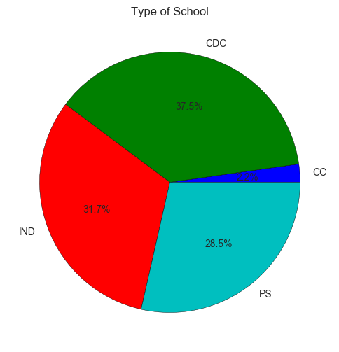

```python
count_school=list(school_type['Count'])
count_school
label_school=list(school_type['GeneralType'])
plt.rcParams["figure.figsize"] = (6,6)
plt.pie(count_school,labels=label_school,autopct='%1.1F%%')
plt.title('Type of School')
plt.show()
```